# Statistical Rethinking

Chapter 7

```r
library(rethinking)
library(tidyverse)
library(reshape2)
```

### Practice

#### Easy

##### Exercise 1

State the three motivating criteria that define information entropy. Try to express each in your own words.

1. The function needs to be continuous, there are no huge jumps in information (in average reduction of uncertainty) as a consequence of small changes in the distribution of probabilities.
2. Information entropy is additive: the uncertainty over a combination of events is the sum over the uncertainty of the two events by themseleves.
3. Information entropy increases as the number of alternatives increases

##### Exercise 2

Suppose a coin is weighted such that, when it is tossed and lands on a table, it comes up heads 70% of the time. What is the entropy of this coin?

```r
p <- c(0.7, 0.3)
i <- -sum(p*log(p))
i
```

```
## [1] 0.6108643
```

##### Exercise 3

Suppose a four-sided die is loaded such that, when tossed onto a table, it shows “1” 20%, “2” 25%, ”3” 25%, and ”4” 30% of the time. What is the entropy of this die?

```r
p <- c(0.2, 0.25, 0.25, 0.3)
i <- -sum(p*log(p))
i
```

```
## [1] 1.376227
```

##### Exercise 4

Suppose another four-sided die is loaded such that it never shows “4”. The other three sides show equally often. What is the entropy of this die?

```r
p <- c(0.33, 0.33, 0.33)
i <- -sum(p*log(p))
i
```

```
## [1] 1.097576
```

#### Medium

##### Exercise 1

Write down and compare the definitions of AIC and WAIC. Which of these criteria is most general? Which assumptions are required to transform the more general criterion into a less general one?

$$\textrm{AIC} = - 2 (\textrm{lppd} - p)$$

with $p$ the number of parameters.

$$\textrm{WAIC} = - 2 (\textrm{lppd} - \sum_i \textrm{var}_{\theta}(\log \textrm{Pr}(y_i|\theta)))$$

WAIC has a different, and more general, definition of the “penalty term”. In particular, AIC’s penalty term is valid only in case of approx. multivariate Normal posterior, flat/noninformative priors and large number of observations.

##### Exercise 2

Explain the difference between model selection and model comparison. What information is lost under model selection?

Model selection narrowly looks at optimizing information criteria, while model comparison has a broader scope that includes verifying causal/inferential assumptions and performing a more thorough model design process.

###### Exercise 3

When comparing models with an information criterion, why must all models be fit to exactly the same observations? What would happen to the information criterion values, if the models were fit to different numbers of observations? Perform some experiments, if you are not sure.

All information criteria attempt to esimate the out-of-sample deviance of the model by first computing the log pointwise predictive density (lppd) of the in-sample data points. Different points have different lppd’s and therefore it does not make sense to compare them. Moreover, a higher (or lower) number of points would alter the “scale” of the values computed.

###### Exercise 4

What happens to the effective number of parameters, as measured by PSIS or WAIC, as a prior becomes more concentrated? Why? Perform some experiments, if you are not sure.

- In WAIC the “effective number of parameters” (the penalty term) is the sum of the variances of the pointwise predictive distributions: these are likely to be smaller if the prior is more concentrated. This is coherent with the fact that tighter priors are useful to avoid overfitting, since the meaning of the penalty is to signal exactly this.
- In PSIS the “effective number of parameters” is the difference between the estimated lppd and the estimated lppd computed with PSIS. Tighter priors, I guess, reduce the importance of the single samples for the majority of the observations, which in turn leads to the PSIS estimate being more similar to the “regular” estimate.

(testing on models from previous chapter)

```r
set.seed(71)
# number of plants
N <- 100
# simulate initial heights
h0 <- rnorm(N, 10, 2)
# assign treatments and simulate fungus and growth
treatment <- rep(0:1, each=N/2)
fungus <- rbinom(N, size=1, prob=0.5 - treatment*0.4)
h1 <- h0 + rnorm(N, 5 - 3*fungus)
# compose a clean data frame
d <- data.frame(h0=h0, h1=h1, treatment=treatment, fungus=fungus)
precis(d)
```

|  | mean | sd | 5.5% | 94.5% | histogram |
| --- | --- | --- | --- | --- | --- |
| h0 | 9.95978 | 2.1011623 | 6.570328 | 13.07874 | ▁▂▂▂▇▃▂▃▁▁▁▁ |
| h1 | 14.39920 | 2.6880870 | 10.618002 | 17.93369 | ▁▁▃▇▇▇▁▁ |
| treatment | 0.50000 | 0.5025189 | 0.000000 | 1.00000 | ▇▁▁▁▁▁▁▁▁▇ |
| fungus | 0.23000 | 0.4229526 | 0.000000 | 1.00000 | ▇▁▁▁▁▁▁▁▁▂ |

```r
m6.8.1 <- quap(alist(h1 ~ dnorm(mu, sigma),
                   mu <- h0 * p,
                   p <- a + bt*treatment,
                   a ~ dlnorm(0, 0.2),
                   bt ~ dnorm(0, 0.5),
                   sigma ~ dexp(1)),
             data=d)

m6.8.2 <- quap(alist(h1 ~ dnorm(mu, sigma),
                   mu <- h0 * p,
                   p <- a + bt*treatment,
                   a ~ dlnorm(0, 1.0),
                   bt ~ dnorm(0, 1.0),
                   sigma ~ dexp(1)),
             data=d)

m6.8.3 <- quap(alist(h1 ~ dnorm(mu, sigma),
                   mu <- h0 * p,
                   p <- a + bt*treatment,
                   a ~ dlnorm(0, 0.01),
                   bt ~ dnorm(0, 0.05),
                   sigma ~ dexp(1)),
             data=d)

compare(m6.8.1, m6.8.2, m6.8.3)
```

|  | WAIC | SE | dWAIC | dSE | pWAIC | weight |
| --- | --- | --- | --- | --- | --- | --- |
| m6.8.1 | 403.0096 | 11.307872 | 0.0000000 | NA | 2.770514 | 5.032560e-01 |
| m6.8.2 | 403.0356 | 11.262466 | 0.0260487 | 0.1783124 | 2.782963 | 4.967440e-01 |
| m6.8.3 | 529.0957 | 9.502234 | 126.0861449 | 13.2405348 | 1.086661 | 2.101505e-28 |

```r
compare(m6.8.1, m6.8.2, m6.8.3, func=PSIS)
```

|  | PSIS | SE | dPSIS | dSE | pPSIS | weight |
| --- | --- | --- | --- | --- | --- | --- |
| m6.8.2 | 402.7865 | 11.306538 | 0.0000000 | NA | 2.680983 | 5.145423e-01 |
| m6.8.1 | 402.9029 | 11.322887 | 0.1163708 | 0.2768493 | 2.714310 | 4.854577e-01 |
| m6.8.3 | 528.7964 | 9.456506 | 126.0098797 | 13.2196533 | 1.072331 | 2.232150e-28 |

Validated!

##### Exercise 5

Provide an informal explanation of why informative priors reduce overfitting.

Informative priors exclude impossible or improbable relationships between the response variable and the predictor(s). Therefore they are less likely to believe in outliers and to modify the fit accordingly.

###### Exercise 6

Provide an informal explanation of why overly informative priors result in underfitting.

If the prior becomes too informative however, the posterior will be dominated by the prior and the likelihood won’t have that much of an influence. Therefore the resulting relationships will be overly biased according to the values on which the priors are centered.

#### Hard

###### Exercise 1

```r
data(Laffer)

precis(Laffer)
```

|  | mean | sd | 5.5% | 94.5% | histogram |
| --- | --- | --- | --- | --- | --- |
| tax_rate | 26.382069 | 8.753579 | 10.9862 | 35.3568 | ▁▁▁▂▁▅▇▂ |
| tax_revenue | 3.306207 | 1.816491 | 1.4336 | 5.7522 | ▁▁▂▇▇▁▂▁▁▁▁▁ |

Normalize tax rate (mean 0 and sd 1) and tax revenue (min 0, max 1):

```r
d <- list()
d$rate <- (Laffer$tax_rate - mean(Laffer$tax_rate)) / sd(Laffer$tax_rate)
d$revenue <- Laffer$tax_revenue / max(Laffer$tax_revenue)
```

Fit a linear model with noninformative priors:

```r
linear <- quap(alist(revenue ~ dnorm(mu, sigma),
                     mu <- a + b*rate,
                     a ~ dlnorm(0.5, 0.5),
                     b ~ dnorm(0, 0.5),
                     sigma ~ dexp(1)),
               data=d)

precis(linear)
```

|  | mean | sd | 5.5% | 94.5% |
| --- | --- | --- | --- | --- |
| a | 0.34496266 | 0.03046054 | 0.296280828 | 0.3936445 |
| b | 0.05773036 | 0.03186563 | 0.006802938 | 0.1086578 |
| sigma | 0.16896021 | 0.02224868 | 0.133402523 | 0.2045179 |

The linear model thinks it is plausible that a slight positive relationship exists. Fitting a quadratic model instead:

```r
quadratic <- quap(alist(revenue ~ dnorm(mu, sigma),
                     mu <- a + b1*rate + b2*rate**2,
                     a ~ dlnorm(0.5, 0.5),
                     b1 ~ dnorm(0, 0.5),
                     b2 ~ dnorm(0, 0.5),
                     sigma ~ dexp(1)),
               data=d)

precis(quadratic)
```

|  | mean | sd | 5.5% | 94.5% |
| --- | --- | --- | --- | --- |
| a | 0.388872401 | 0.03674047 | 0.33015404 | 0.44759076 |
| b1 | -0.004041339 | 0.04258072 | -0.07209356 | 0.06401088 |
| b2 | -0.049687882 | 0.02405076 | -0.08812565 | -0.01125012 |
| sigma | 0.160665468 | 0.02115047 | 0.12686294 | 0.19446800 |

Fitting a cubic model:

```r
cubic <- quap(alist(revenue ~ dnorm(mu, sigma),
                     mu <- a + b1*rate + b2*rate**2 + b3*rate**3,
                     a ~ dlnorm(0.5, 0.5),
                     b1 ~ dnorm(0, 0.5),
                     b2 ~ dnorm(0, 0.5),
                     b3 ~ dnorm(0, 0.5),
                     sigma ~ dexp(1)),
               data=d)

precis(cubic)
```

|  | mean | sd | 5.5% | 94.5% |
| --- | --- | --- | --- | --- |
| a | 0.42152691 | 0.04362158 | 0.35181121 | 0.491242612 |
| b1 | 0.02591819 | 0.04678995 | -0.04886119 | 0.100697578 |
| b2 | -0.12266689 | 0.05784104 | -0.21510804 | -0.030225747 |
| b3 | -0.02978140 | 0.02141226 | -0.06400233 | 0.004439529 |
| sigma | 0.15731883 | 0.02070668 | 0.12422556 | 0.190412100 |

These models seem to think that there is some curved relationships between the two variables. Plotting the predictions (mean and 89% confidence interal) it can be seen that such curves, although they are not as extreme as the one reported in the book, predict a negative relationship for high tax rates…

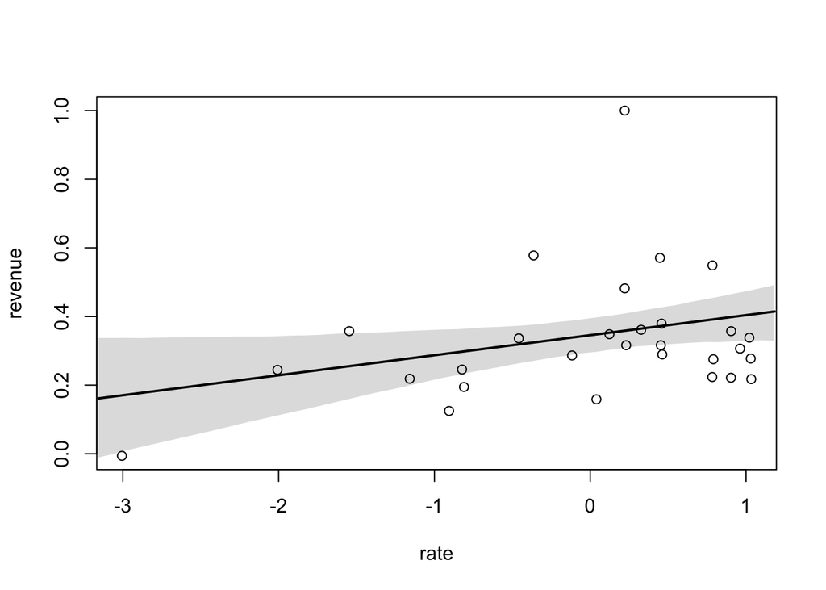

```r
xseq <- seq(from=min(d$rate)-0.15, to=max(d$rate)+0.15, length.out=50)
mu <- link(linear, data=list(rate=xseq))
mu_mean <- apply(mu, 2, mean)
mu_PI <- apply(mu, 2, PI)
plot(revenue ~ rate, data=d)
lines(xseq, mu_mean, lwd=2)
shade(mu_PI, xseq)
```

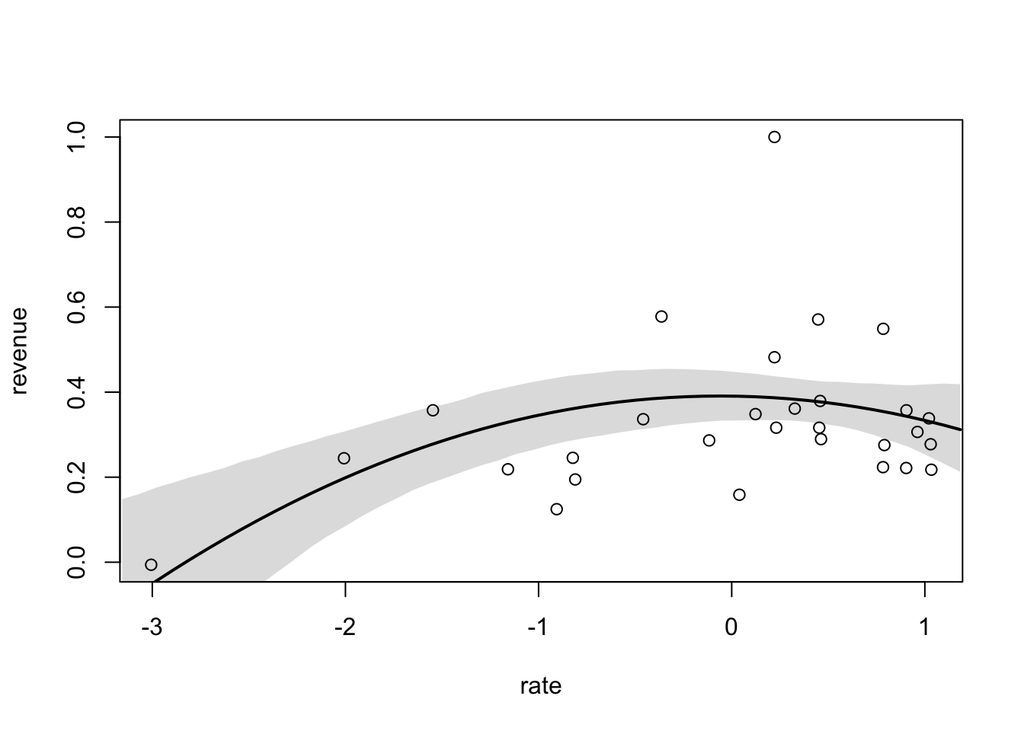

```r
mu <- link(quadratic, data=list(rate=xseq))
mu_mean <- apply(mu, 2, mean)
mu_PI <- apply(mu, 2, PI)
plot(revenue ~ rate, data=d)
lines(xseq, mu_mean, lwd=2)
shade(mu_PI, xseq)
```

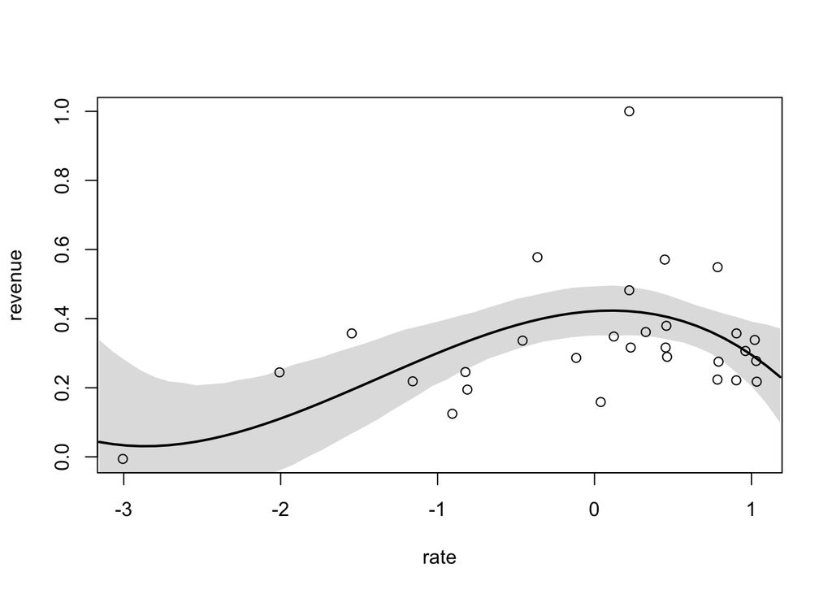

```r
mu <- link(cubic, data=list(rate=xseq))
mu_mean <- apply(mu, 2, mean)
mu_PI <- apply(mu, 2, PI)
plot(revenue ~ rate, data=d)
lines(xseq, mu_mean, lwd=2)
shade(mu_PI, xseq)
```

However:

```r
compare(linear, quadratic, cubic)
```

|  | WAIC | SE | dWAIC | dSE | pWAIC | weight |
| --- | --- | --- | --- | --- | --- | --- |
| linear | -8.439116 | 21.88193 | 0.0000000 | NA | 6.753014 | 0.4712488 |
| quadratic | -7.848311 | 23.94437 | 0.5908044 | 3.345298 | 8.252415 | 0.3507185 |
| cubic | -6.492278 | 23.04091 | 1.9468381 | 3.738079 | 9.274050 | 0.1780327 |

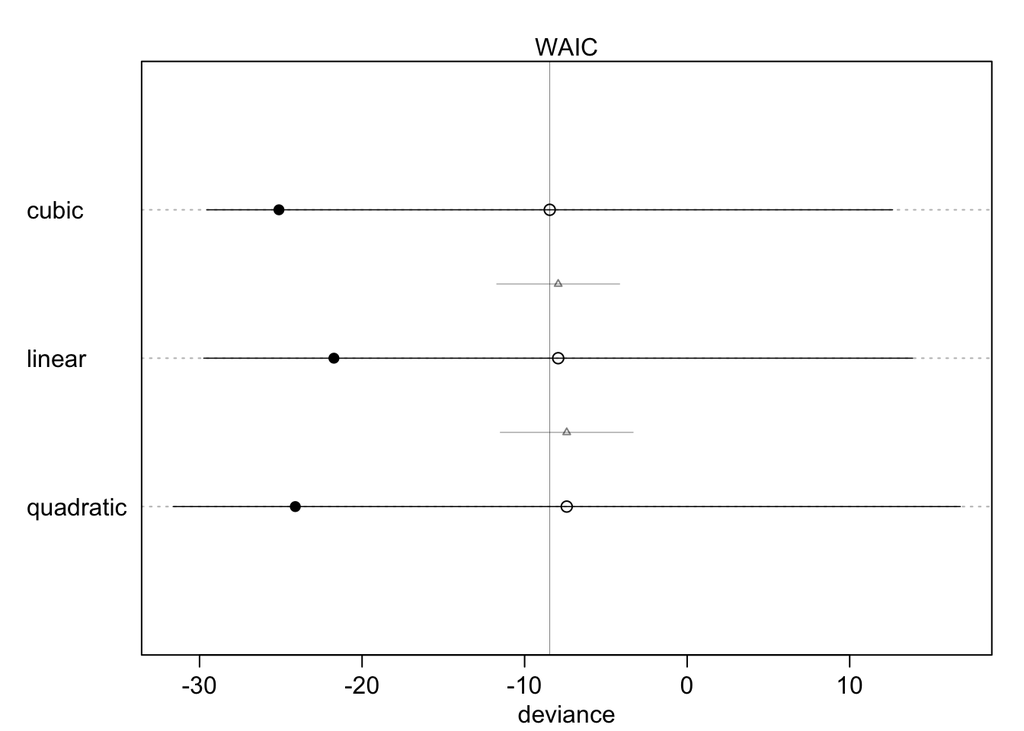

```r
plot(compare(linear, quadratic, cubic))
```

##### Exercise 2

In the $\texttt{Laffer}$ data, there is one country with a high tax revenue that is an outlier. Use PSIS and WAIC to measure the importance of this outlier in the models you fit in the previous problem. Then use robust regression with a Student’s t distribution to revisit the curve fitting problem. How much does a curved relationship depend upon the outlier point?

- Detect outlier for the three models:

```r
WAIC(linear, pointwise=TRUE)$WAIC
```

```
##  [1]  0.5187396 -1.5016933 -1.1581561 -1.4855613 -1.5496492 -1.2400393
##  [7] -0.5365677 -0.3296460 -1.6618421 -1.5817328  0.9200341 22.8295840
## [13] -0.1018741 -1.0946717 -1.6815494 -1.6162683 -1.6789854 -1.6732082
## [19] -0.6691349 -1.5650753 -1.4241686 -1.5947239 -1.4823641 -1.3123591
## [25] -1.1579986 -0.5918588 -0.4537777 -0.2619882 -1.0208570
```

```r
WAIC(quadratic, pointwise=TRUE)$WAIC
```

```
##  [1] -0.40504671 -1.50365877 -1.39950157 -1.17943687 -1.15306598 -0.50115236
##  [7]  0.65644689  0.53884449 -1.65588611 -1.31231387 -0.09967205 22.81068363
## [13] -0.17118515 -1.39588312 -1.70472408 -1.57350313 -1.75621300 -1.77390332
## [19] -0.07771863 -1.61993220 -1.45662406 -1.71372786 -1.68691005 -1.66146541
## [25] -1.47718287 -1.00242196 -1.06132275 -1.10313512 -1.55633502
```

```r
WAIC(cubic, pointwise=TRUE)$WAIC
```

```
##  [1]  0.12599501 -0.45640459 -0.09685765 -1.54520121 -1.39994735 -0.84139979
##  [7]  0.05614343  1.52735542 -1.66211463 -1.01063892 -0.23692184 20.03186241
## [13] -0.57425348 -1.61454385 -1.52989530 -1.29534763 -1.65394807 -1.76518664
## [19] -0.04366843 -1.44236380 -1.20572984 -1.70810483 -1.57889934 -1.72974052
## [25] -1.52664533 -1.02904193 -1.26465086 -1.44129623 -1.67752618
```

```r
WAIC(linear, pointwise=TRUE)$WAIC[12]
```

```
## [1] 22.30317
```

```r
WAIC(quadratic, pointwise=TRUE)$WAIC[12]
```

```
## [1] 23.48163
```

```r
WAIC(cubic, pointwise=TRUE)$WAIC[12]
```

```
## [1] 21.05898
```

Point 12 is an outlier…

Trying “robust” regression:

```r
linear <- quap(alist(revenue ~ dstudent(2, mu, sigma),
                     mu <- a + b*rate,
                     a ~ dlnorm(0.5, 0.5),
                     b ~ dnorm(0, 0.5),
                     sigma ~ dexp(1)),
               data=d)

precis(linear)
```

|  | mean | sd | 5.5% | 94.5% |
| --- | --- | --- | --- | --- |
| a | 0.29721564 | 0.01942882 | 0.2661646334 | 0.32826665 |
| b | 0.03749647 | 0.02366133 | -0.0003189064 | 0.07531184 |
| sigma | 0.08190581 | 0.01767684 | 0.0536548117 | 0.11015681 |

```r
quadratic <- quap(alist(revenue ~ dstudent(2, mu, sigma),
                     mu <- a + b1*rate + b2*rate**2,
                     a ~ dlnorm(0.5, 0.5),
                     b1 ~ dnorm(0, 0.5),
                     b2 ~ dnorm(0, 0.5),
                     sigma ~ dexp(1)),
               data=d)

precis(quadratic)
```

|  | mean | sd | 5.5% | 94.5% |
| --- | --- | --- | --- | --- |
| a | 0.329564267 | 0.02503745 | 0.28954958 | 0.36957895 |
| b1 | 0.001958814 | 0.02754470 | -0.04206294 | 0.04598056 |
| b2 | -0.035138684 | 0.01296405 | -0.05585774 | -0.01441963 |
| sigma | 0.074440674 | 0.01600517 | 0.04886132 | 0.10002003 |

```r
cubic <- quap(alist(revenue ~ dstudent(2, mu, sigma),
                     mu <- a + b1*rate + b2*rate**2 + b3*rate**3,
                     a ~ dlnorm(0.5, 0.5),
                     b1 ~ dnorm(0, 0.5),
                     b2 ~ dnorm(0, 0.5),
                     b3 ~ dnorm(0, 0.5),
                     sigma ~ dexp(1)),
               data=d)

precis(cubic)
```

|  | mean | sd | 5.5% | 94.5% |
| --- | --- | --- | --- | --- |
| a | 0.335597488 | 0.02678673 | 0.29278712 | 0.378407853 |
| b1 | 0.017173386 | 0.03776138 | -0.04317660 | 0.077523371 |
| b2 | -0.055038397 | 0.03799699 | -0.11576492 | 0.005688128 |
| b3 | -0.008340655 | 0.01548012 | -0.03308088 | 0.016399571 |
| sigma | 0.074248638 | 0.01639422 | 0.04804751 | 0.100449766 |

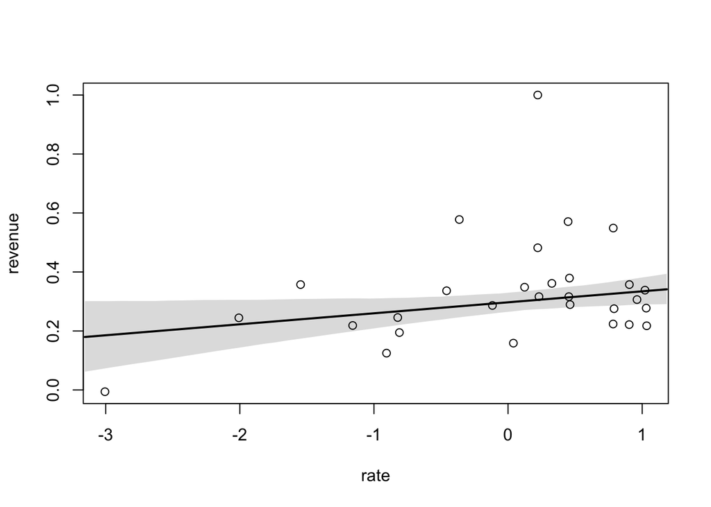

```r
xseq <- seq(from=min(d$rate)-0.15, to=max(d$rate)+0.15, length.out=50)
mu <- link(linear, data=list(rate=xseq))
mu_mean <- apply(mu, 2, mean)
mu_PI <- apply(mu, 2, PI)
plot(revenue ~ rate, data=d)
lines(xseq, mu_mean, lwd=2)
shade(mu_PI, xseq)
```

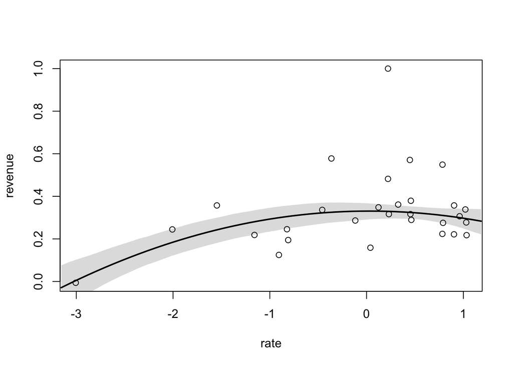

```r
mu <- link(quadratic, data=list(rate=xseq))
mu_mean <- apply(mu, 2, mean)
mu_PI <- apply(mu, 2, PI)
plot(revenue ~ rate, data=d)
lines(xseq, mu_mean, lwd=2)
shade(mu_PI, xseq)
```

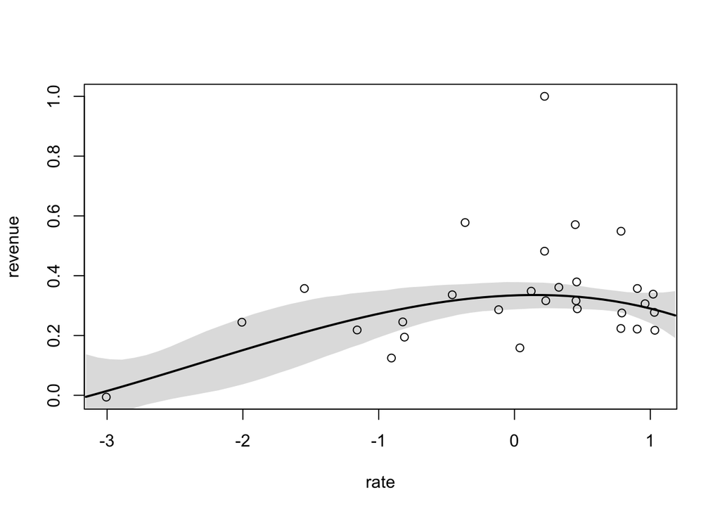

```r
mu <- link(cubic, data=list(rate=xseq))
mu_mean <- apply(mu, 2, mean)
mu_PI <- apply(mu, 2, PI)
plot(revenue ~ rate, data=d)
lines(xseq, mu_mean, lwd=2)
shade(mu_PI, xseq)
```

The predictions are certainly less negative now: the outlier had lots of influence using normal distribution!

##### Exercise 3

Consider three fictional Polynesian islands. On each there is a Royal Ornithologist charged by the king with surveying the bird population. They have each found the following proportions of 5 important bird species:

```r
A <- c(0.2, 0.8, 0.05)
B <- c(0.2, 0.1, 0.15)
C <- c(0.2, 0.05, 0.7)
D <- c(0.2, 0.025, 0.05)
E <- c(0.2, 0.025, 0.05)

df <- cbind(A, B, C, D, E)
rownames(df) <- c("I1", "I2", "I3")

df
```

```
##       A    B    C     D     E
## I1 0.20 0.20 0.20 0.200 0.200
## I2 0.80 0.10 0.05 0.025 0.025
## I3 0.05 0.15 0.70 0.050 0.050
```

Notice that each row sums to 1, all the birds. This problem has two parts. It is not computationally complicated. But it is conceptually tricky. First, compute the entropy of each island’s bird distribution. Interpret these entropy values.

```r
I1_E <- sum(-df[1,]*log(df[1,]))
I2_E <- sum(-df[2,]*log(df[2,]))
I3_E <- sum(-df[3,]*log(df[3,]))

I1_E
```

```
## [1] 1.609438
```

```r
I2_E
```

```
## [1] 0.7430039
```

```r
I3_E
```

```
## [1] 0.9836003
```

```r
# first island has the highest I.E. because there are uniform proportions, therefore the avg reduction in uncertainty is higher than in other cases
```

Second, use each island’s bird distribution to predict the other two. This means to compute the K-L Divergence of each island from the others, treating each island as if it were a statistical model of the other islands. You should end up with 6 different K-L Divergence values. Which island predicts the others best? Why?

First island predicting second, third

```r
sum(-df[2,]*log(df[1,]))
```

```
## [1] 1.609438
```

```r
sum(-df[3,]*log(df[1,]))
```

```
## [1] 1.609438
```

Second island predicting first, third

```r
sum(-df[1,]*log(df[2,]))
```

```
## [1] 2.579844
```

```r
sum(-df[3,]*log(df[2,]))
```

```
## [1] 2.822445
```

Third island predicting first, second

```r
sum(-df[1,]*log(df[3,]))
```

```
## [1] 2.248198
```

```r
sum(-df[2,]*log(df[3,]))
```

```
## [1] 2.753918
```

The first island is the best at predicting the others: in fact using its proportions you won’t be surprised no matter which bird appears. Conversely, the second and the third island proportions do a worse job and they are particularly bad at predicting each other since they assign high probabilities to different species (A and C).

##### Exercise 4

Recall the marriage, age, and happiness collider bias example from Chapter 6. Run models $\texttt{m6.9}$ and $\texttt{m6.10}$ again. Compare these two models using WAIC (or LOO, they will produce identical results). Which model is expected to make better predictions? Which model provides the correct causal inference about the influence of age on happiness? Can you explain why the answers to these two questions disagree?

```r
d <- sim_happiness(seed=1977, N_years=1000)
precis(d)
```

|  | mean | sd | 5.5% | 94.5% | histogram |
| --- | --- | --- | --- | --- | --- |
| age | 3.300000e+01 | 18.768883 | 4.000000 | 62.000000 | ▇▇▇▇▇▇▇▇▇▇▇▇▇ |
| married | 3.007692e-01 | 0.458769 | 0.000000 | 1.000000 | ▇▁▁▁▁▁▁▁▁▃ |
| happiness | -1.000070e-16 | 1.214421 | -1.789474 | 1.789474 | ▇▅▇▅▅▇▅▇ |

```r
d2 <- d[d$age>17,] # only adults
d2$A <- (d2$age - 18) / (65 - 18)

d2$mid <- d2$married + 1

m6.9 <- quap(alist(happiness ~ dnorm(mu, sigma),
                   mu <- a[mid] + bA*A,
                   a[mid] ~ dnorm(0, 1),
                   bA ~ dnorm(0, 2),
                   sigma ~ dexp(1)),
             data=d2)
precis(m6.9, depth=2)
```

|  | mean | sd | 5.5% | 94.5% |
| --- | --- | --- | --- | --- |
| a[1] | -0.2350877 | 0.06348986 | -0.3365568 | -0.1336186 |
| a[2] | 1.2585517 | 0.08495989 | 1.1227694 | 1.3943340 |
| bA | -0.7490274 | 0.11320112 | -0.9299447 | -0.5681102 |
| sigma | 0.9897080 | 0.02255800 | 0.9536559 | 1.0257600 |

```r
m6.10 <- quap(alist(happiness ~ dnorm(mu, sigma),
                    mu <- a + bA*A,
                    a ~ dnorm(0, 1),
                    bA ~ dnorm(0, 2),
                    sigma ~ dexp(1)),
              data=d2)
precis(m6.10)
```

|  | mean | sd | 5.5% | 94.5% |
| --- | --- | --- | --- | --- |
| a | 1.649248e-07 | 0.07675015 | -0.1226614 | 0.1226617 |
| bA | -2.728620e-07 | 0.13225976 | -0.2113769 | 0.2113764 |
| sigma | 1.213188e+00 | 0.02766080 | 1.1689803 | 1.2573949 |

```r
compare(m6.9, m6.10)
```

|  | WAIC | SE | dWAIC | dSE | pWAIC | weight |
| --- | --- | --- | --- | --- | --- | --- |
| m6.9 | 2713.971 | 37.54465 | 0.0000 | NA | 3.738532 | 1.000000e+00 |
| m6.10 | 3101.906 | 27.74379 | 387.9347 | 35.40032 | 2.340445 | 5.768312e-85 |

```r
compare(m6.9, m6.10, func=PSIS)
```

|  | PSIS | SE | dPSIS | dSE | pPSIS | weight |
| --- | --- | --- | --- | --- | --- | --- |
| m6.9 | 2714.289 | 37.53161 | 0.0000 | NA | 3.878050 | 1.000000e+00 |
| m6.10 | 3101.901 | 27.69888 | 387.6116 | 35.34503 | 2.337216 | 6.779832e-85 |

$\texttt{m6.9}$ seems to work better although it gives the wrong inferential conclusions concerning the relationship among age and happiness. The idea is that knowing the marriage status of the individual helps in predicting happiness because married and unmarried persons at each age have different happiness distributions. Therefore it provides useful information for prediction (while age by itself is not informative by design) but it is not useful when it comes to establishing the causes of happiness.

###### Exercise 5

1. avgfood + groupsize + area
2. avgfood + groupsize
3. groupsize + area
4. avgfood
5. area

Can you explain the relative differences in WAIC scores, using the fox DAG from last week’s homework? Be sure to pay attention to the standard error of the score differences (dSE).

```r
data(foxes)

precis(foxes)
```

|  | mean | sd | 5.5% | 94.5% | histogram |
| --- | --- | --- | --- | --- | --- |
| group | 17.2068966 | 8.0027357 | 4.00000 | 28.6750 | ▃▅▇▇▇▇ |
| avgfood | 0.7517241 | 0.1983158 | 0.42000 | 1.2100 | ▁▂▂▃▇▁▂▁▁▁ |
| groupsize | 4.3448276 | 1.5385111 | 2.00000 | 8.0000 | ▁▃▁▇▁▂▁▁▁▁▁▁ |
| area | 3.1691379 | 0.9283539 | 1.77875 | 5.0700 | ▁▂▃▅▅▇▁▁▂ |
| weight | 4.5296552 | 1.1840226 | 2.78000 | 6.2905 | ▁▁▂▅▇▇▅▅▃▃▁▁▁ |

```r
d <- list()
d$W <- standardize(foxes$weight)
d$A <- standardize(foxes$area)
d$G <- standardize(foxes$groupsize)
d$F <- standardize(foxes$avgfood)

model_1 <- quap(alist(W ~ dnorm(mu, sigma),
                     mu <- a + bF*F + bG*G+ bA*A,
                     a ~ dnorm(0, 0.2),
                     bG ~ dnorm(0, 0.5),
                     bF ~ dnorm(0, 0.5),
                     bA ~ dnorm(0, 0.5),
                     sigma ~ dexp(1)),
               data = d)

precis(model_1)
```

|  | mean | sd | 5.5% | 94.5% |
| --- | --- | --- | --- | --- |
| a | -2.408257e-07 | 0.07936203 | -0.126836098 | 0.1268356 |
| bG | -6.396198e-01 | 0.18161488 | -0.929875433 | -0.3493641 |
| bF | 2.968996e-01 | 0.20960029 | -0.038082112 | 0.6318814 |
| bA | 2.782376e-01 | 0.17011232 | 0.006365232 | 0.5501099 |
| sigma | 9.312067e-01 | 0.06100014 | 0.833716665 | 1.0286967 |

```r
model_2 <- quap(alist(W ~ dnorm(mu, sigma),
                     mu <- a + bF*F + bG*G,
                     a ~ dnorm(0, 0.2),
                     bF ~ dnorm(0, 0.5),
                     bG ~ dnorm(0, 0.5),
                     sigma ~ dexp(1)),
               data = d)

precis(model_2)
```

|  | mean | sd | 5.5% | 94.5% |
| --- | --- | --- | --- | --- |
| a | 1.728373e-09 | 0.08013768 | -0.1280755 | 0.1280755 |
| bF | 4.772501e-01 | 0.17912245 | 0.1909778 | 0.7635224 |
| bG | -5.735234e-01 | 0.17914094 | -0.8598252 | -0.2872216 |
| sigma | 9.420385e-01 | 0.06175167 | 0.8433474 | 1.0407296 |

```r
model_3 <- quap(alist(W ~ dnorm(mu, sigma),
                     mu <- a + bG*G+ bA*A,
                     a ~ dnorm(0, 0.2),
                     bG ~ dnorm(0, 0.5),
                     bA ~ dnorm(0, 0.5),
                     sigma ~ dexp(1)),
               data = d)

precis(model_3)
```

|  | mean | sd | 5.5% | 94.5% |
| --- | --- | --- | --- | --- |
| a | -8.334279e-07 | 0.08013101 | -0.1280657 | 0.1280640 |
| bG | -4.819988e-01 | 0.14537256 | -0.7143322 | -0.2496654 |
| bA | 4.058504e-01 | 0.14536254 | 0.1735330 | 0.6381678 |
| sigma | 9.419451e-01 | 0.06159401 | 0.8435060 | 1.0403842 |

```r
model_4 <- quap(alist(W ~ dnorm(mu, sigma),
                     mu <- a + bF*F,
                     a ~ dnorm(0, 0.2),
                     bF ~ dnorm(0, 0.5),
                     sigma ~ dexp(1)),
               data = d)

precis(model_4)
```

|  | mean | sd | 5.5% | 94.5% |
| --- | --- | --- | --- | --- |
| a | 5.593046e-07 | 0.08360020 | -0.1336087 | 0.1336098 |
| bF | -2.421258e-02 | 0.09088506 | -0.1694645 | 0.1210393 |
| sigma | 9.911444e-01 | 0.06465866 | 0.8878074 | 1.0944814 |

```r
model_5 <- quap(alist(W ~ dnorm(mu, sigma),
                     mu <- a + bA*A,
                     a ~ dnorm(0, 0.2),
                     bA ~ dnorm(0, 0.5),
                     sigma ~ dexp(1)),
               data = d)

precis(model_5)
```

|  | mean | sd | 5.5% | 94.5% |
| --- | --- | --- | --- | --- |
| a | 1.410074e-09 | 0.08360867 | -0.1336228 | 0.1336228 |
| bA | 1.883359e-02 | 0.09089582 | -0.1264355 | 0.1641027 |
| sigma | 9.912661e-01 | 0.06466649 | 0.8879166 | 1.0946156 |

```r
compare(model_1, model_2, model_3, model_4, model_5)
```

|  | WAIC | SE | dWAIC | dSE | pWAIC | weight |
| --- | --- | --- | --- | --- | --- | --- |
| model_1 | 323.2384 | 16.30962 | 0.0000000 | NA | 4.828847 | 0.385980679 |
| model_2 | 323.6879 | 16.10271 | 0.4495864 | 3.358331 | 3.648213 | 0.308275579 |
| model_3 | 323.7320 | 15.76867 | 0.4936802 | 3.108595 | 3.636476 | 0.301553435 |
| model_4 | 333.4691 | 13.83617 | 10.2307452 | 7.171364 | 2.431423 | 0.002317328 |
| model_5 | 333.8949 | 13.89930 | 10.6565137 | 7.226231 | 2.708263 | 0.001872979 |

```r
compare(model_1, model_2, model_3, model_4, model_5, func=PSIS)
```

|  | PSIS | SE | dPSIS | dSE | pPSIS | weight |
| --- | --- | --- | --- | --- | --- | --- |
| model_1 | 323.2744 | 16.48265 | 0.0000000 | NA | 4.883660 | 0.394410959 |
| model_3 | 323.6619 | 15.84908 | 0.3875301 | 3.001136 | 3.602621 | 0.324936033 |
| model_2 | 323.9876 | 16.19054 | 0.7131954 | 3.612737 | 3.784631 | 0.276108998 |
| model_4 | 333.4264 | 13.90165 | 10.1520199 | 7.312347 | 2.429343 | 0.002463008 |
| model_5 | 333.7635 | 13.85939 | 10.4890884 | 7.353241 | 2.675874 | 0.002081001 |

avgfood and area did not seem to be important predictors by themselves because their effect is masked. The situation improves by adding groupsize in models 2 and 3, with 3 performing slightly better. finally, the model 1 is the overall best as the separate positive causal effects of both area and avgfood are included.